# Random Forest

#### Random forest is same as bagging , but we have a very small difference

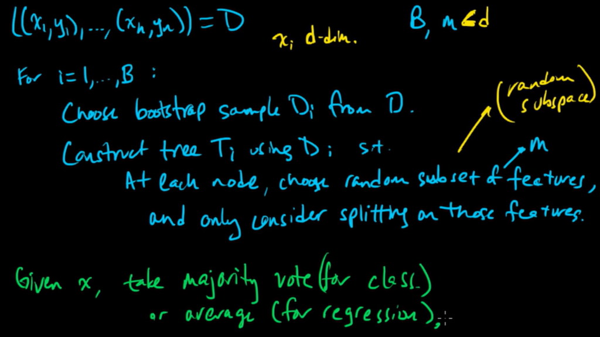

### We follow the following steps

#### 1) Let our Dataset be D , having 'd' number of features

#### 2) Next we create a bootstrap samples from D by resampling with replacement

#### 3) Now we grow the decision tree (say Ti) for each bootstrap sample (say Di)

#### 4) So in Random forest , at each node of our tree we do not consider all the features for best split , instead we connsider only a subset of feature to create a best split to our tree.

#### 5) In our modern Random forest algorithm of growing a tree , we make sure to consider all the features in our tree , by changing the subset features at each nodes. This subset of features are referred to as the Random subspace

#### 6) Typically, for a classification problem with p features, √p (rounded down) features are used in each split.For regression problems the inventors recommend p/3 (rounded down) with a minimum node size of 5 as the default.In practice the best values for these parameters will depend on the problem, and they should be treated as tuning parameters

### What is the benefit of Random Forest over bagging ?

#### The reason for doing this is the correlation of the trees in an ordinary bootstrap sample: if one or a few features are very strong predictors for the response variable (target output), these features will be selected in many of the B trees, causing them to become correlated. To avoid this and to increase our performance ,we consider building trees in amost possible ways ,hence we use the Random forest method

#### So we can say that Random forest helps in avoiding highly correlated trees

#### An interesting point to note is that the averaging highly correlated trees gives a high variance than in decorrelated trees . So as a result we now have an increased perfomance in predictions

### Result

#### for a given x , take the majority vote of y from all our samples ( in case of Classification )

#### for a given x , take the mean of y from all our samples ( in case of Regression )